# Week 1 - Homework

STAT 420, Summer 2017, Megan Masanz, netId: mjneuman

May 22, 2017

## Exercise 1

For this exercise, we will use the `diabetes` dataset from the `faraway` package.

```r
library(faraway)
```

**(b)** Coerce the data to be a tibble instead of a data frame.

```r
library(tibble)
diabetes = as_tibble(diabetes)
```

- Observations are in this dataset: **403**

```r
nrow(diabetes)
```

```
## [1] 403
```

- Number of variables in the dataset **19**

```r
ncol(diabetes)
```

```
## [1] 19
```

```r
str(diabetes)
```

```
## Classes 'tbl_df', 'tbl' and 'data.frame':    403 obs. of  19 variables:
##  $ id      :Class 'labelled'  atomic [1:403] 1000 1001 1002 1003 1005 1008 1011 1015 1016 1022 ...
##   .. ..- attr(*, "label")= chr "Subject ID"
##  $ chol    :Class 'labelled'  atomic [1:403] 203 165 228 78 249 248 195 227 177 263 ...
##   .. ..- attr(*, "label")= chr "Total Cholesterol"
##  $ stab.glu:Class 'labelled'  atomic [1:403] 82 97 92 93 90 94 92 75 87 89 ...
##   .. ..- attr(*, "label")= chr "Stabilized Glucose"
##  $ hdl     :Class 'labelled'  atomic [1:403] 56 24 37 12 28 69 41 44 49 40 ...
##   .. ..- attr(*, "label")= chr "High Density Lipoprotein"
##  $ ratio   :Class 'labelled'  atomic [1:403] 3.6 6.9 6.2 6.5 8.9 ...
##   .. ..- attr(*, "label")= chr "Cholesterol/HDL Ratio"
##  $ glyhb   :Class 'labelled'  atomic [1:403] 4.31 4.44 4.64 4.63 7.72 ...
##   .. ..- attr(*, "label")= chr "Glycosolated Hemoglobin"
##  $ location: Factor w/ 2 levels "Buckingham","Louisa": 1 1 1 1 1 1 1 1 1 1 ...
##  $ age     : atomic  46 29 58 67 64 34 30 37 45 55 ...
##   ..- attr(*, "units")= chr "years"
##  $ gender  : Factor w/ 2 levels "male","female": 2 2 2 1 1 1 1 1 1 2 ...
##  $ height  : atomic  62 64 61 67 68 71 69 59 69 63 ...
##   ..- attr(*, "units")= chr "inches"
##  $ weight  : atomic  121 218 256 119 183 190 191 170 166 202 ...
##   ..- attr(*, "units")= chr "pounds"
##  $ frame   : Factor w/ 3 levels "small","medium",..: 2 3 3 3 2 3 2 2 3 1 ...
##  $ bp.1s   :Class 'labelled'  atomic [1:403] 118 112 190 110 138 132 161 NA 160 108 ...
##   .. ..- attr(*, "label")= chr "First Systolic Blood Pressure"
##  $ bp.1d   :Class 'labelled'  atomic [1:403] 59 68 92 50 80 86 112 NA 80 72 ...
##   .. ..- attr(*, "label")= chr "First Diastolic Blood Pressure"
##  $ bp.2s   :Class 'labelled'  atomic [1:403] NA NA 185 NA NA NA 161 NA 128 NA ...
##   .. ..- attr(*, "label")= chr "Second Systolic Blood Pressure"
##   .. ..- attr(*, "comment")= chr "equals first measurement if it was not high"
##  $ bp.2d   :Class 'labelled'  atomic [1:403] NA NA 92 NA NA NA 112 NA 86 NA ...
##   .. ..- attr(*, "comment")= chr "equals first measurement if it was not high"
##   .. ..- attr(*, "label")= chr "Second Diastolic Blood Pressure"
##  $ waist   : atomic  29 46 49 33 44 36 46 34 34 45 ...
##   ..- attr(*, "units")= chr "inches"
##  $ hip     : atomic  38 48 57 38 41 42 49 39 40 50 ...
##   ..- attr(*, "units")= chr "inches"
##  $ time.ppn:Class 'labelled'  atomic [1:403] 720 360 180 480 300 195 720 1020 300 240 ...
##   .. ..- attr(*, "label")= chr "Postprandial Time when Labs were Drawn"
##   .. ..- attr(*, "units")= chr "minutes"
```

- The dataset is composed of **403 African Americans in central Virginia**.
  - Ranging in age from 19-92
  - Number of Males: 169 and Number of Females: 234

```r
range(diabetes$age)
```

```
## [1] 19 92
```

```r
nrow(diabetes[ diabetes$gender == "male", ])
```

```
## [1] 169
```

```r
nrow(diabetes[ diabetes$gender == "female", ])
```

```
## [1] 234
```

**(c)** The following list provides the factor variables of the diabetes dataset

- location
- gender
- frame

```r
v = sapply(diabetes, is.factor, simplify = TRUE)
v[which(v == TRUE)]
```

```
## location   gender    frame
##     TRUE     TRUE     TRUE
```

**(d)** The mean [HDL](https://en.wikipedia.org/wiki/High-density_lipoprotein) level (High Density Lipoprotein) of individuals in this sample is **50.4452736**

```r
mean(diabetes$hdl, na.rm = TRUE)
```

```
## [1] 50.44527
```

**(e)** The standard deviation of total cholesterol of individuals in this sample is **44.4455574**

```r
sd(diabetes$chol, na.rm = TRUE)
```

```
## [1] 44.44556
```

**(f)** The range ages of individuals in this sample is from **19** to **92**.

```r
range(diabetes$age)
```

```
## [1] 19 92
```

**(g)** The mean HDL of females in this sample is **52.1111111**

```r
mean(diabetes[ diabetes$gender == "female", ]$hdl)
```

```
## [1] 52.11111
```

**(h)** The Scatter plot of HDL (y-axis) vs weight (x-axis) found below shows there seems to be a relationship between the two variables. The scatter plot appears to show a negative correlation (as weight increases, HDL decreases).

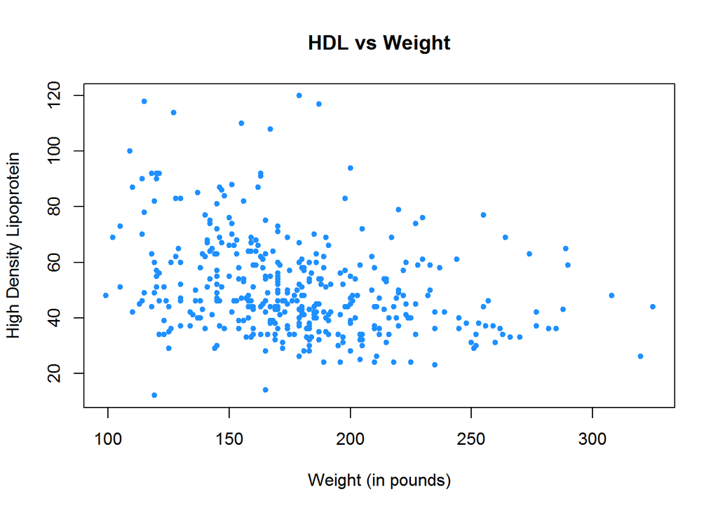

```r
plot(hdl ~ weight, data = diabetes,
     xlab = "Weight (in pounds)",
     ylab = "High Density Lipoprotein",
     main = "HDL vs Weight",
     pch  = 20,
     cex  = 1,
     col  = "dodgerblue")
```

**(i)** Based on the scatter plot of total cholesterol (y-axis) vs weight (x-axis) found below there does not appear to be a relationship between the two variables. There does not seem to be a slope of the line of best fit for this data.

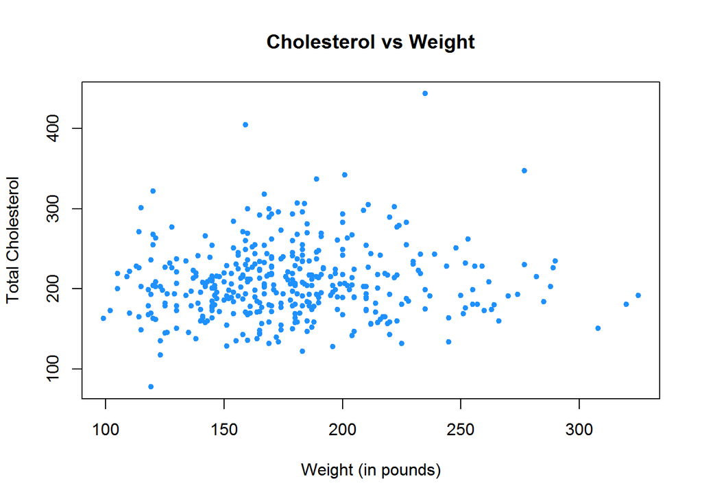

```r
plot(chol ~ weight, data = diabetes,
     xlab = "Weight (in pounds)",
     ylab = "Total Cholesterol",
     main = "Cholesterol vs Weight",
     pch  = 20,
     cex  = 1,
     col  = "dodgerblue")
```

**(j)** Below are the boxplots for HDL by gender. Based on the boxplot, there seems to be a difference between HDL levels for the 2 genders. The median shows to be slightly higher for females, and based on the box plot the IQR is smaller for females than for males. There also appears to be a higher number of interesting points/outliers in females than males.

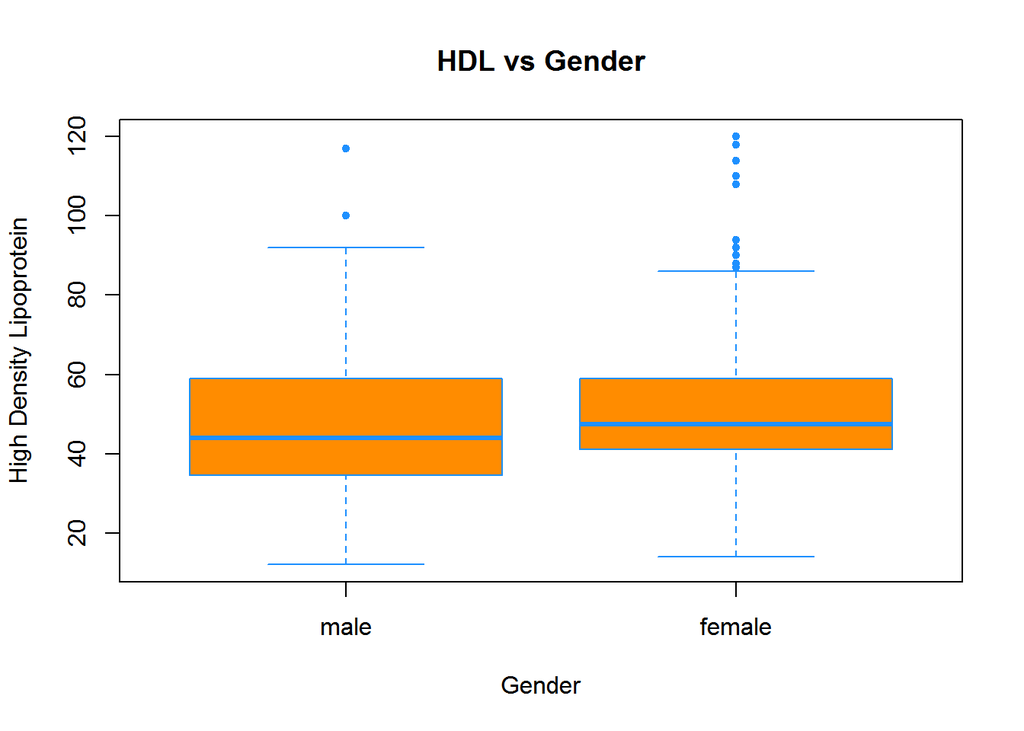

```r
boxplot(hdl ~ gender, data = diabetes,
        xlab   = "Gender",
        ylab   = "High Density Lipoprotein",
        main   = "HDL vs Gender",
        pch    = 20,
        cex    = 1,
        col    = "darkorange",
        border = "dodgerblue")
```

## Exercise 2

For this exercise we will use the data stored in `nutrition.csv`.

```r
library(readr)
nutrition = read_csv("nutrition.csv")
```

It contains the nutritional values per serving size for a large variety of foods as calculated by the USDA. It is a cleaned version totaling 5138 observations and is current as of September 2015.

The variables in the dataset are:

- `ID`
- `Desc` - Short description of food
- `Water` - in grams
- `Calories` - in kcal
- `Protein` - in grams
- `Fat` - in grams
- `Carbs` - Carbohydrates, in grams
- `Fiber` - in grams
- `Sugar` - in grams
- `Calcium` - in milligrams
- `Potassium` - in milligrams
- `Sodium` - in milligrams
- `VitaminC` - Vitamin C, in milligrams
- `Chol` - Cholesterol, in milligrams
- `Portion` - Description of standard serving size used in analysis

**(a)** Below is a histogram of `Calories` with `R`’s default bin selection. The histogram is showing a right skewed shape with an interesting increase in values between 350-400.

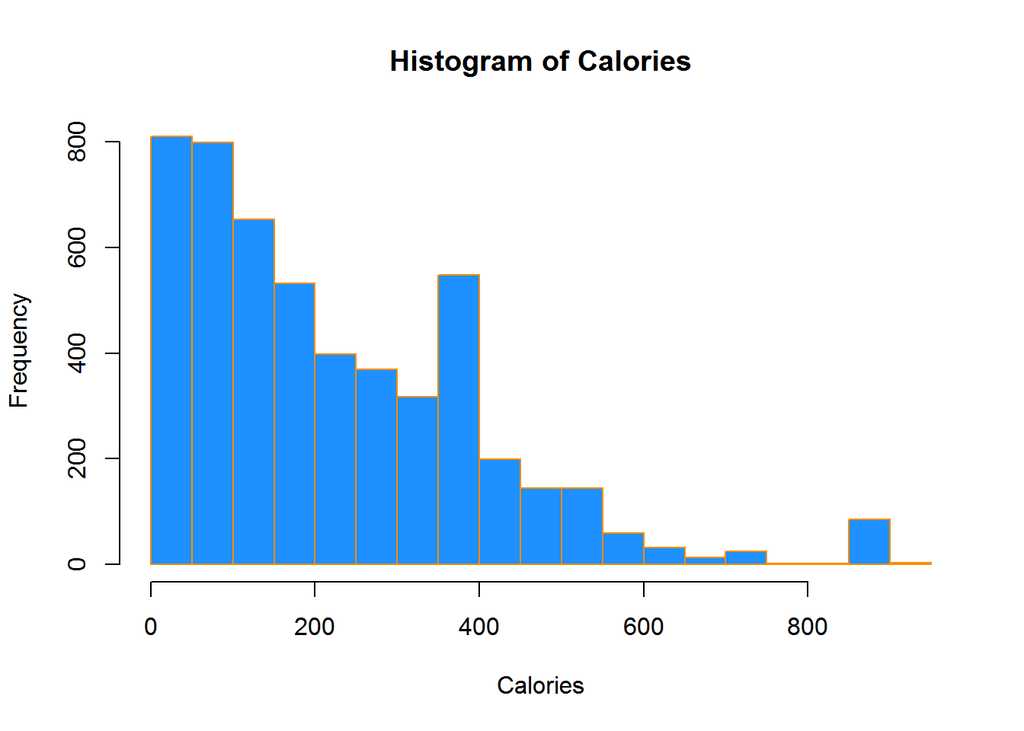

```r
hist(nutrition$Calories,
     xlab   = "Calories",
     main   = "Histogram of Calories",
     col    = "dodgerblue",
     border = "darkorange")
```

**(b)** Below is a scatter plot of calories (y-axis) vs protein (x-axis). One trend is that the standard deviation for Calories seems to decrease as protein increases. Based on the high variability, a good prediction could not be made on the calories in food based on protein alone.

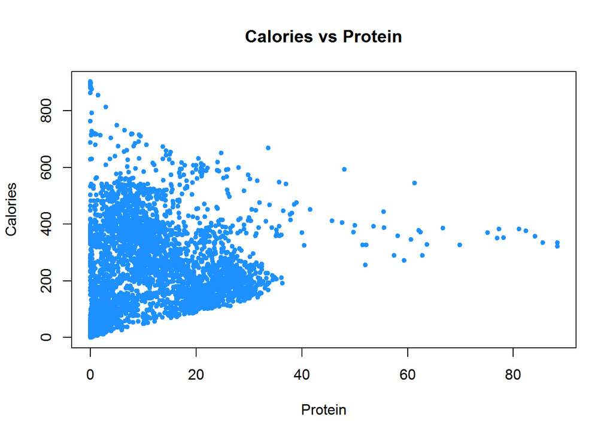

```r
plot(Calories ~ Protein, data = nutrition,
     xlab = "Protein",
     ylab = "Calories",
     main = "Calories vs Protein",
     pch  = 20,
     cex  = 1,
     col  = "dodgerblue")
```

**(c)** Below is a scatter plot of `Calories` (y-axis) vs `4 * Protein + 4 * Carbs + 9 * Fat + 2 * Fiber` (x-axis).

The results of this equation provide a straight line with some variability which could be due to a variety of factors. As an example in a given serving size the calories could be within a range of values.

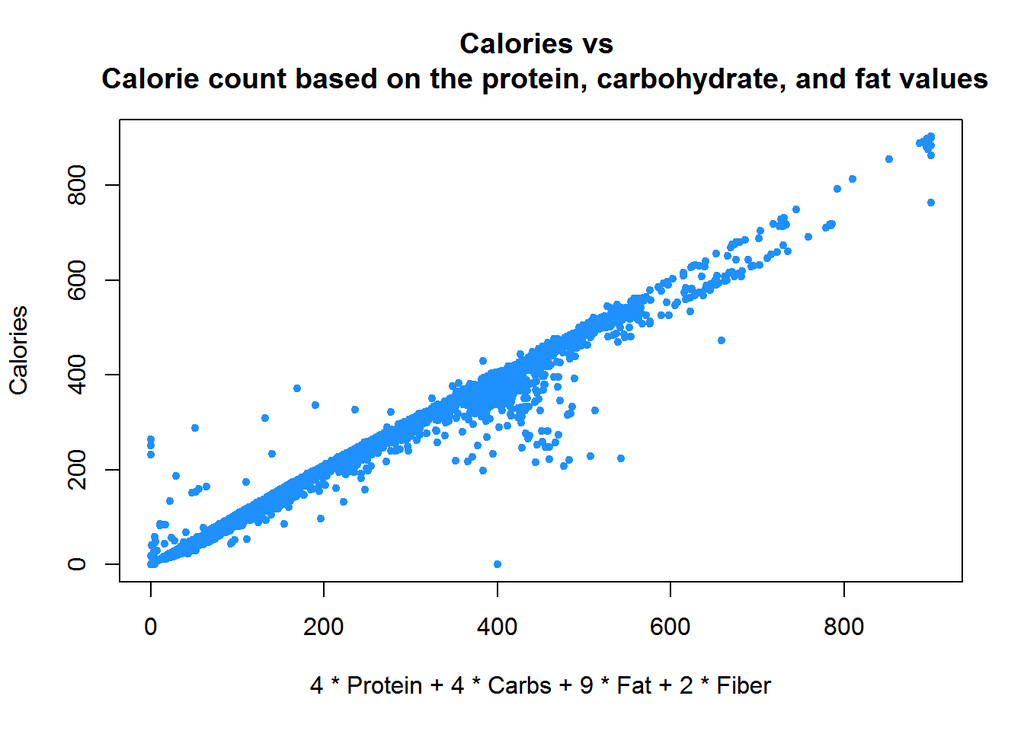

```r
calorieCalc = 4 * nutrition$Protein + 4 * nutrition$Carbs + 9 * nutrition$Fat + 2 * nutrition$Fiber
nutrition = cbind(nutrition, calorieCalc)

plot(Calories ~ calorieCalc, data = nutrition,
     xlab = "4 * Protein + 4 * Carbs + 9 * Fat + 2 * Fiber",
     ylab = "Calories",
     main = "Calories vs \n Calorie count based on the protein, carbohydrate, and fat values",
     pch  = 20,
     cex  = 1,
     col  = "dodgerblue")
```

## Exercise 3

For each of the following parts, use the following vectors:

```r
a = 1:10
b = 10:1
c = rep(1, times = 10)
d = 2 ^ (1:10)
```

**(a)** Function called `sum_of_squares`.

- Arguments:
  - A vector of numeric data `x`.
- Output:
  - The sum of the squares of the elements of the vector. $\sum_{i = 1}^n x_i^2$

Provide your function, as well as the result of running the following code:

```r
sum_of_squares = function(x){
  sum(x ^ 2)
}
```

```r
sum_of_squares(x = a)
```

```
## [1] 385
```

```r
sum_of_squares(x = c(c, d))
```

```
## [1] 1398110
```

**(b)** Write a function called `rms_diff`.

- Arguments:
  - A vector of numeric data `x`.
  - A vector of numeric data `y`.
- Output:
  - $\sqrt{\frac{1}{n}\sum_{i = 1}^n (x_i - y_i)^{2}}$

Provide your function, as well as the result of running the following code:

```r
rms_diff = function (x, y){
    sqrt(  (1/length(x)) * sum(( x - y) ^ 2))
}
```

```r
rms_diff(x = a, y = b)
```

```
## [1] 5.744563
```

```r
rms_diff(x = d, y = c)
```

```
## [1] 373.3655
```

```r
rms_diff(x = d, y = 1)
```

```
## [1] 373.3655
```

```r
rms_diff(x = a, y = 0) ^ 2 * length(a)
```

```
## [1] 385
```